# Week3_R_Solutions

John Grando

January 20, 2017

## Week 3 Solutions

This is the published version for the Week 3 assignment

Question - 4 Meaningful question for analysis: Please state at the beginning a meaningful question for analysis. Use the first three steps and anything else that would be helpful to answer the question you are posing from the data set you chose. Please write a brief conclusion paragraph in R markdown at the end.

I have selected a data set which reports a simulated building heating and cooling load based on a varying set of inputs (https://archive.ics.uci.edu/ml/datasets/Energy+efficiency). To provide some background, I am a mechanical engineer who specializes in building energy simulation which is why I found this data set particularly interesting. Since I haven’t seen the actually energy simulation, i’m unsure of many input parameters which could greatly affect the results. Therefore, I’ll be treating this as just a data set with numbers rather than a summarey on modeling analysis.

It appears this data was constructed in order to determine how two response variables, cooling load and heating load, will vary given changes in a number of tracked predictor variables. The main question I set out to answer is, which variables have the greatest impact on the cooling and heating loads for the modeled buildings?

First, I will take the data and import it into data tables. During my analysis, it seemed like some plotting functions (e.g. geom_histogram) did not work well wtih numberical and categorical data. To get the best plots possible, I created two data tables; one where all the colums are character type, and the other with numerical types where applicable.

```r
eedataurl <- "https://github.com/john-grando/Masters/raw/master/Workshop/R/Week3/assignment/ENB2012_data.csv"
eedata <- read.csv(file = eedataurl,
                   header = TRUE, sep <- ",",
                   #colClasses = c("numeric","numeric","numeric","numeric", "numeric", "character", "numeric", "character", "numeric", "numeric"),
                   colClasses = c("character","character","character","character", "character", "character", "character", "character", "numeric", "numeric"),
                   col.names = c("relative.compactness","surface.area","wall.area","roof.area","overall.height","orientation","glazing.area","glazing.area.distribution","heating.load","cooling.load"),
                   stringsAsFactors = FALSE)
eedatanumeric <- read.csv(file = eedataurl,
                          header = TRUE, sep <- ",",
                          colClasses = c("numeric","numeric","numeric","numeric","numeric","character","numeric","character","numeric","numeric"),
                          col.names = c("relative.compactness","surface.area","wall.area","roof.area","overall.height","orientation","glazing.area","glazing.area.distribution","heating.load","cooling.load"),
                          stringsAsFactors = FALSE)
```

Question 2 - Data wrangling: Please perform some basic transformations. They will need to make sense but could include column renaming, creating a subset of the data, replacing values, or creating new columns with derived data (for example – if it makes sense you could sum two columns together)

From the data provided, it appears that glazing area is actually the glazing ratio. We can then calculate an extra column which gives the actual glazing area.

```r
eedata$glazing.area.actual <- formatC(eedatanumeric$glazing.area * eedatanumeric$wall.area)
eedatanumeric$glazing.area.actual <- eedatanumeric$glazing.area * eedatanumeric$wall.area
```

Question 1 - Data Exploration: This should include summary statistics, means, medians, quartiles, or any other relevant information about the data set. Please include some conclusions in the R Markdown text.

To start, I take a look at the histograms of the two response variables in this study (cooling load and heating load)

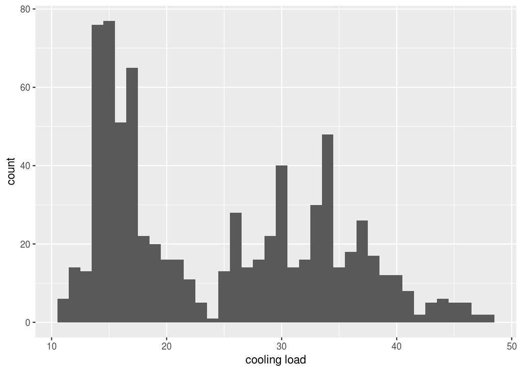

```r
require(ggplot2)
ggplot(eedata, aes(x = cooling.load)) + geom_histogram(binwidth = 1) + labs(x = "cooling load")
```

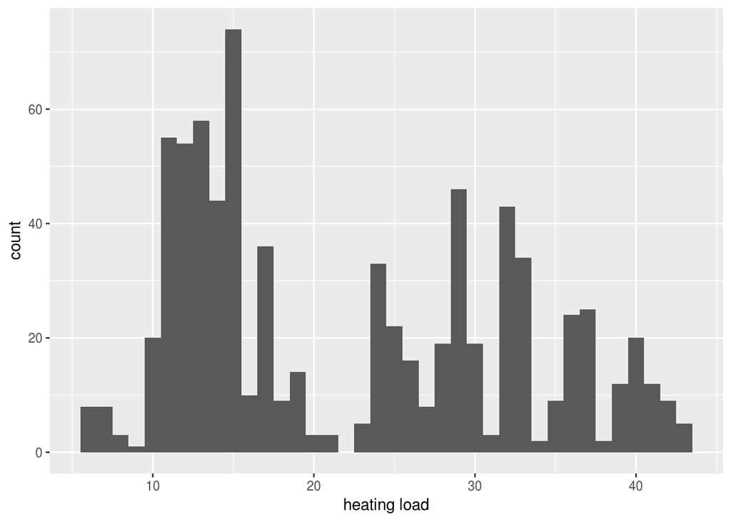

```r
ggplot(eedata, aes(x = heating.load)) + geom_histogram(binwidth = 1) + labs(x = "heating load")
```

Upon inspection, it appears both of these response variables are bimodal. Therefore, I will check whether there are any inputs influencing this shape.

First, i’ll check categorical fields of orientation and glazing area distribution since a linear regression wouldn’t provide any meaningful results

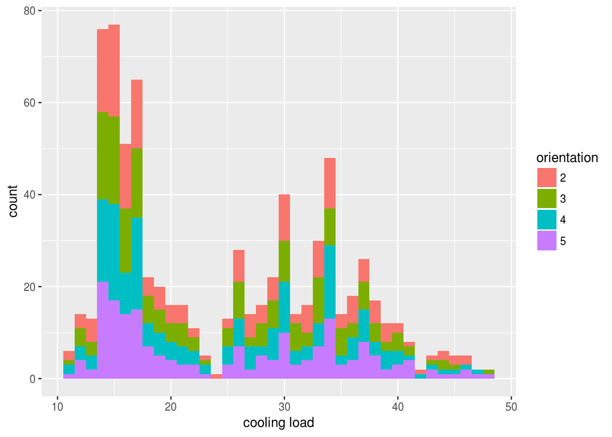

```r
ggplot(eedata, aes(cooling.load, fill = orientation)) + geom_histogram(binwidth = 1) + labs(x = "cooling load")
```

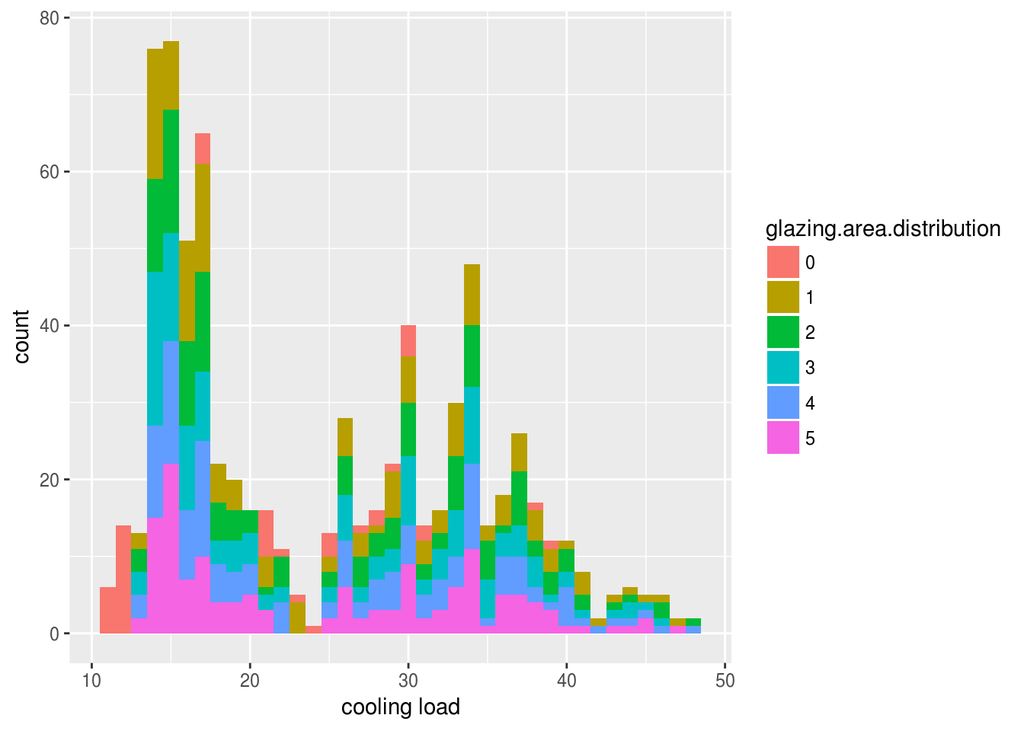

```r
ggplot(eedata, aes(cooling.load, fill = glazing.area.distribution)) + geom_histogram(binwidth = 1) + labs(x = "cooling load")
```

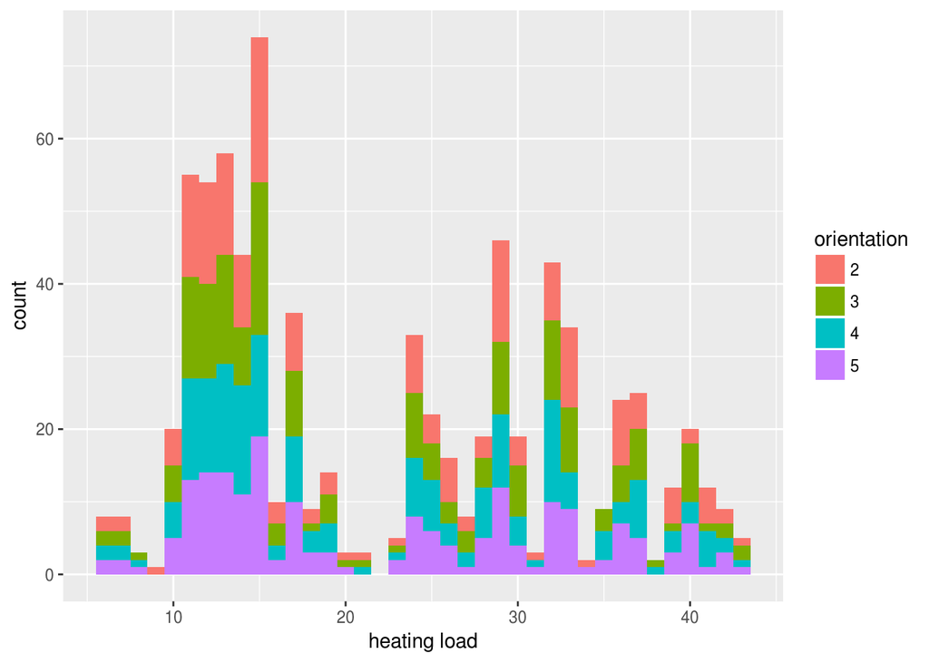

```r
ggplot(eedata, aes(heating.load, fill = orientation)) + geom_histogram(binwidth = 1) + labs(x = "heating load")
```

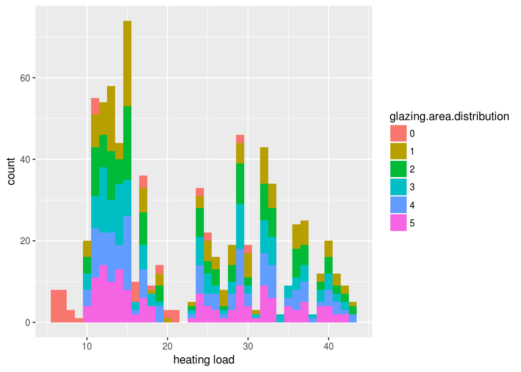

```r
ggplot(eedata, aes(heating.load, fill = glazing.area.distribution)) + geom_histogram(binwidth = 1) + labs(x = "heating load")
```

It does not appear that these attributes are influencing the bimodal nature of the cooling or heating response variables.

I then start with checking the numeric fields in reference to the cooling response variable. For the following steps, I will be using the lm() function to check for correlation. I realize that a lot or results show weak r squared values but i’m using more of a check rather than a proof of strong relationships.

```r
testlm <- lm(cooling.load ~ relative.compactness, data = eedatanumeric)
summary(testlm)
```

```
##
## Call:
## lm(formula = cooling.load ~ relative.compactness, data = eedatanumeric)
##
## Residuals:
##     Min      1Q  Median      3Q     Max
## -15.571  -5.632  -1.233   3.379  21.968
##
## Coefficients:
##                      Estimate Std. Error t value Pr(>|t|)
## (Intercept)           -19.008      1.938  -9.809   <2e-16 ***
## relative.compactness   57.051      2.512  22.710   <2e-16 ***
## ---
## Signif. codes:  0 '***' 0.001 '**' 0.01 '*' 0.05 '.' 0.1 ' ' 1
##
## Residual standard error: 7.359 on 766 degrees of freedom
## Multiple R-squared:  0.4024, Adjusted R-squared:  0.4016
## F-statistic: 515.8 on 1 and 766 DF,  p-value: < 2.2e-16
```

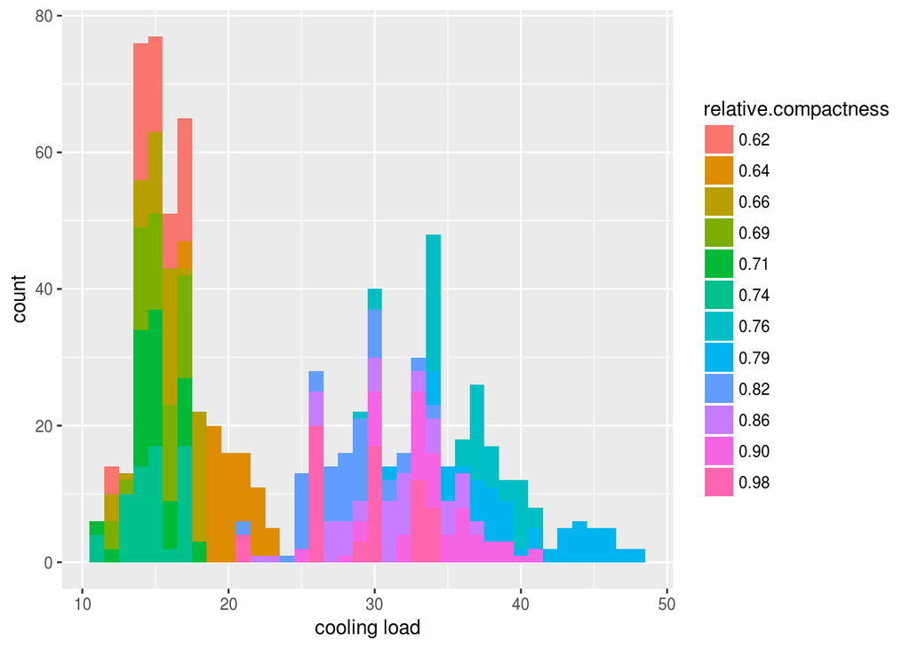

```r
ggplot(eedata, aes(x = cooling.load, fill = relative.compactness)) + geom_histogram(binwidth = 1) + labs(x = "cooling load")
```

```r
testlm <- lm(cooling.load ~ surface.area, data = eedatanumeric)
summary(testlm)
```

```
##
## Call:
## lm(formula = cooling.load ~ surface.area, data = eedatanumeric)
##
## Residuals:
##      Min       1Q   Median       3Q      Max
## -14.6843  -5.3800  -0.5586   3.7048  20.9195
##
## Coefficients:
##               Estimate Std. Error t value Pr(>|t|)
## (Intercept)  73.410157   1.955287   37.54   <2e-16 ***
## surface.area -0.072684   0.002886  -25.18   <2e-16 ***
## ---
## Signif. codes:  0 '***' 0.001 '**' 0.01 '*' 0.05 '.' 0.1 ' ' 1
##
## Residual standard error: 7.041 on 766 degrees of freedom
## Multiple R-squared:  0.4529, Adjusted R-squared:  0.4522
## F-statistic: 634.2 on 1 and 766 DF,  p-value: < 2.2e-16
```

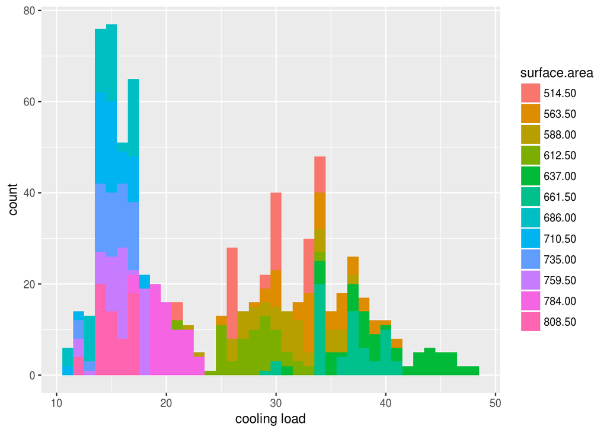

```r
ggplot(eedata, aes(x = cooling.load, fill = surface.area)) + geom_histogram(binwidth = 1) + labs(x = "cooling load")
```

```r
testlm <- lm(cooling.load ~ wall.area, data = eedatanumeric)
summary(testlm)
```

```
##
## Call:
## lm(formula = cooling.load ~ wall.area, data = eedatanumeric)
##
## Residuals:
##     Min      1Q  Median      3Q     Max
## -17.111  -6.664  -0.909   7.331  21.160
##
## Coefficients:
##              Estimate Std. Error t value Pr(>|t|)
## (Intercept) -5.076775   2.290183  -2.217   0.0269 *
## wall.area    0.093138   0.007124  13.074   <2e-16 ***
## ---
## Signif. codes:  0 '***' 0.001 '**' 0.01 '*' 0.05 '.' 0.1 ' ' 1
##
## Residual standard error: 8.608 on 766 degrees of freedom
## Multiple R-squared:  0.1824, Adjusted R-squared:  0.1814
## F-statistic: 170.9 on 1 and 766 DF,  p-value: < 2.2e-16
```

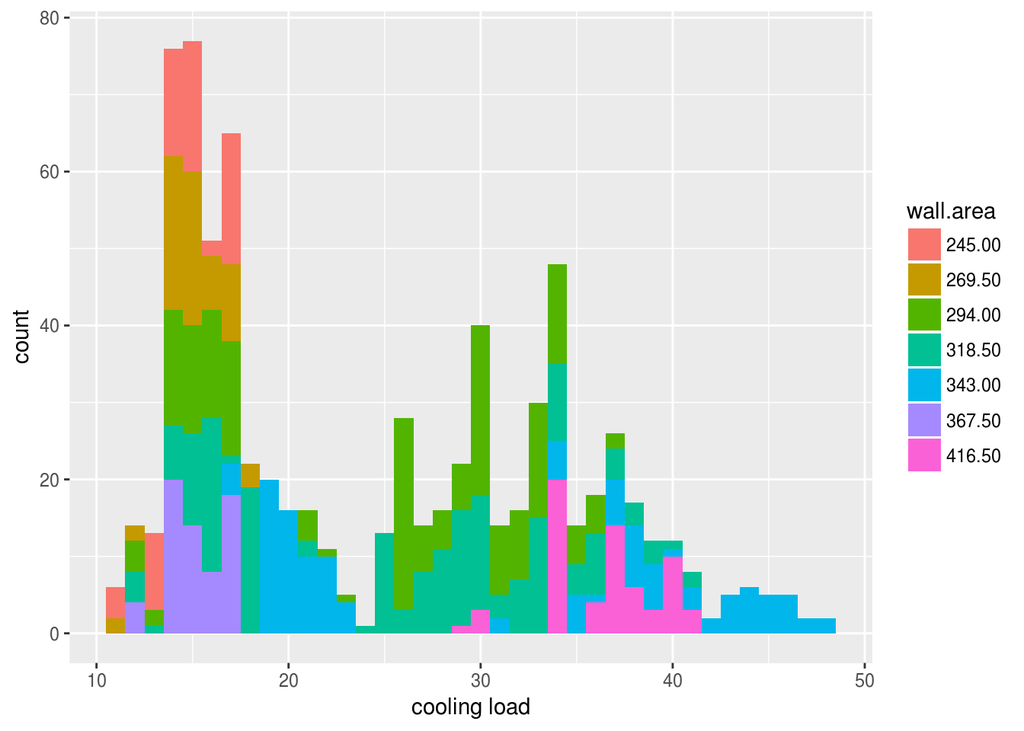

```r
ggplot(eedata, aes(x = cooling.load, fill = wall.area)) + geom_histogram(binwidth = 1) + labs(x = "cooling load")
```

```r
testlm <- lm(cooling.load ~ glazing.area, data = eedatanumeric)
summary(testlm)
```

```
##
## Call:
## lm(formula = cooling.load ~ glazing.area, data = eedatanumeric)
##
## Residuals:
##     Min      1Q  Median      3Q     Max
## -12.462  -9.049  -1.536   8.127  21.151
##
## Coefficients:
##              Estimate Std. Error t value Pr(>|t|)
## (Intercept)   21.1148     0.6803  31.036  < 2e-16 ***
## glazing.area  14.8180     2.5240   5.871 6.46e-09 ***
## ---
## Signif. codes:  0 '***' 0.001 '**' 0.01 '*' 0.05 '.' 0.1 ' ' 1
##
## Residual standard error: 9.312 on 766 degrees of freedom
## Multiple R-squared:  0.04306,    Adjusted R-squared:  0.04181
## F-statistic: 34.47 on 1 and 766 DF,  p-value: 6.457e-09
```

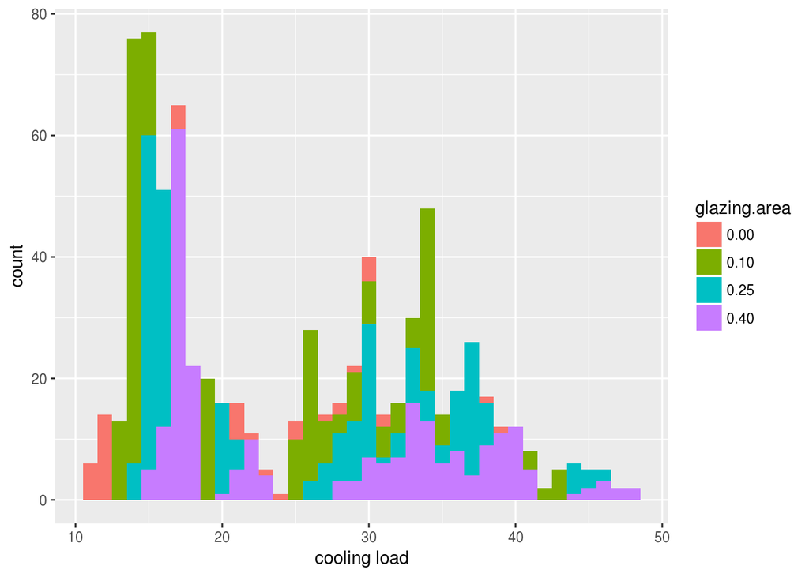

```r
ggplot(eedata, aes(x = cooling.load, fill = glazing.area)) + geom_histogram(binwidth = 1) + labs(x = "cooling load")
```

```r
testlm <- lm(cooling.load ~ glazing.area.actual, data = eedatanumeric)
summary(testlm)
```

```
##
## Call:
## lm(formula = cooling.load ~ glazing.area.actual, data = eedatanumeric)
##
## Residuals:
##     Min      1Q  Median      3Q     Max
## -13.290  -8.522  -1.286   7.942  21.364
##
## Coefficients:
##                      Estimate Std. Error t value Pr(>|t|)
## (Intercept)         19.736783   0.645142  30.593   <2e-16 ***
## glazing.area.actual  0.064984   0.007445   8.728   <2e-16 ***
## ---
## Signif. codes:  0 '***' 0.001 '**' 0.01 '*' 0.05 '.' 0.1 ' ' 1
##
## Residual standard error: 9.079 on 766 degrees of freedom
## Multiple R-squared:  0.09046,    Adjusted R-squared:  0.08927
## F-statistic: 76.18 on 1 and 766 DF,  p-value: < 2.2e-16
```

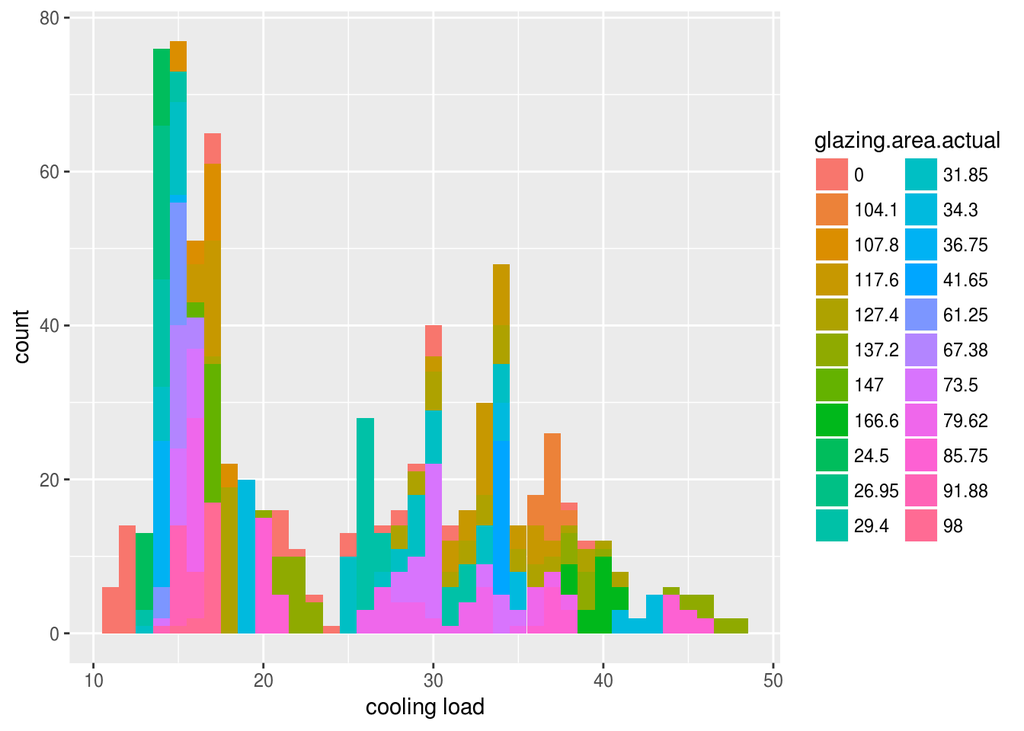

```r
ggplot(eedata, aes(x = cooling.load, fill = glazing.area.actual)) + geom_histogram(binwidth = 1) + labs(x = "cooling load")
```

While some of these show a correlation between surface properties and cooling load, the overall height and roof area are clearly the dominant factors

```r
testlm <- lm(cooling.load ~ overall.height, data = eedatanumeric)
summary(testlm)
```

```
##
## Call:
## lm(formula = cooling.load ~ overall.height, data = eedatanumeric)
##
## Residuals:
##      Min       1Q   Median       3Q      Max
## -11.9441  -2.3539  -0.2664   2.0386  14.9259
##
## Coefficients:
##                Estimate Std. Error t value Pr(>|t|)
## (Intercept)    -0.96122    0.48283  -1.991   0.0469 *
## overall.height  4.86647    0.08725  55.777   <2e-16 ***
## ---
## Signif. codes:  0 '***' 0.001 '**' 0.01 '*' 0.05 '.' 0.1 ' ' 1
##
## Residual standard error: 4.231 on 766 degrees of freedom
## Multiple R-squared:  0.8024, Adjusted R-squared:  0.8022
## F-statistic:  3111 on 1 and 766 DF,  p-value: < 2.2e-16
```

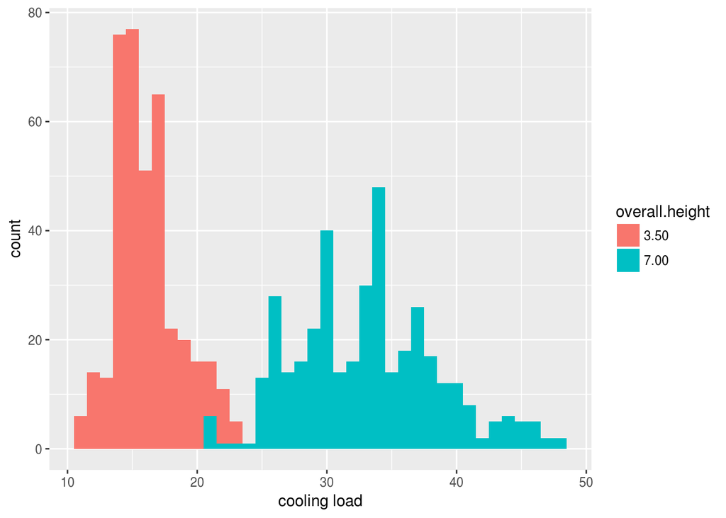

```r
ggplot(eedata, aes(x = cooling.load, fill = overall.height)) + geom_histogram(binwidth = 1) + labs(x = "cooling load")
```

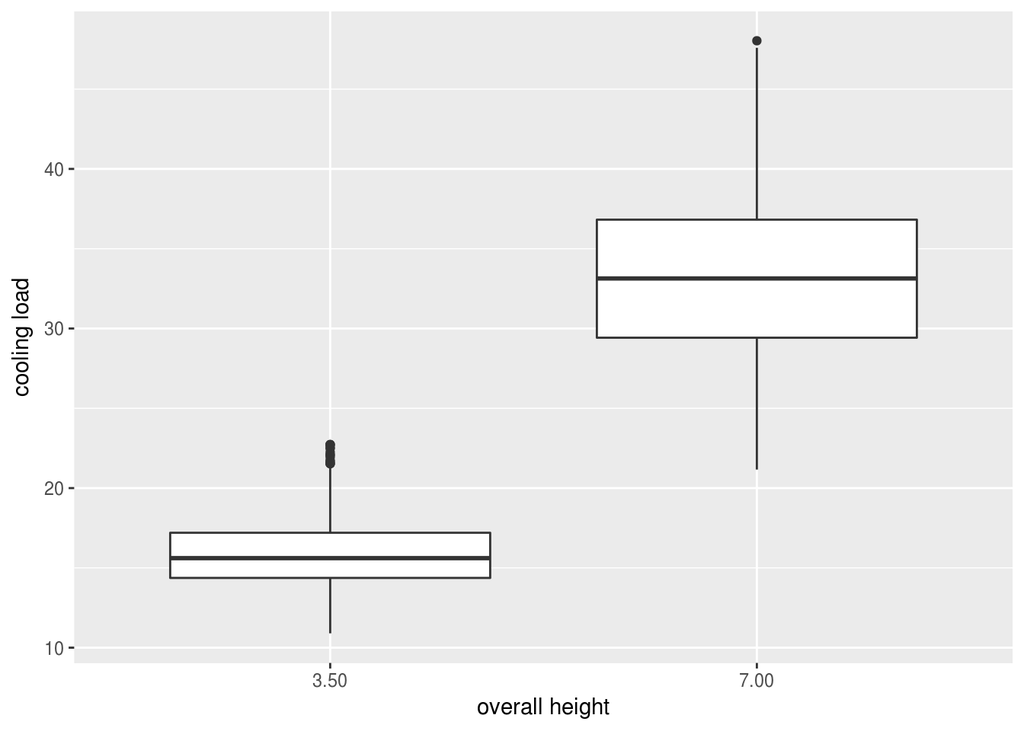

```r
ggplot(eedata, aes(y = cooling.load, x = overall.height)) + geom_boxplot() + labs(x = "overall height", y = "cooling load")
```

```r
testlm <- lm(cooling.load ~ roof.area, data = eedatanumeric)
summary(testlm)
```

```
##
## Call:
## lm(formula = cooling.load ~ roof.area, data = eedatanumeric)
##
## Residuals:
##      Min       1Q   Median       3Q      Max
## -15.3129  -2.4653  -0.6178   2.4377  18.0638
##
## Coefficients:
##              Estimate Std. Error t value Pr(>|t|)
## (Intercept) 56.672891   0.701905   80.74   <2e-16 ***
## roof.area   -0.181678   0.003851  -47.18   <2e-16 ***
## ---
## Signif. codes:  0 '***' 0.001 '**' 0.01 '*' 0.05 '.' 0.1 ' ' 1
##
## Residual standard error: 4.817 on 766 degrees of freedom
## Multiple R-squared:  0.744,  Adjusted R-squared:  0.7437
## F-statistic:  2226 on 1 and 766 DF,  p-value: < 2.2e-16
```

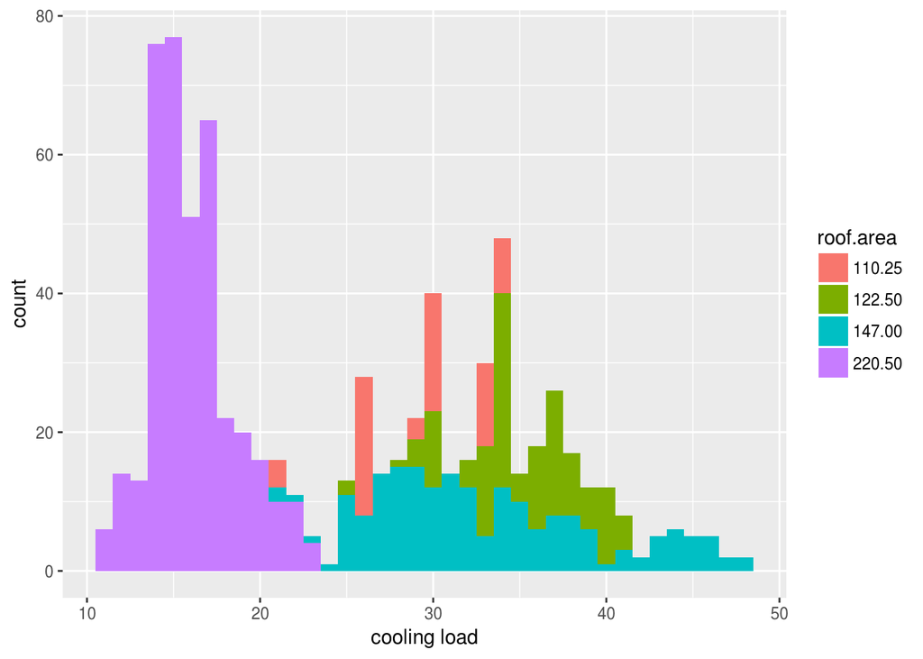

```r
ggplot(eedata, aes(x = cooling.load, fill = roof.area)) + geom_histogram(binwidth = 1) + labs(x = "cooling load")
```

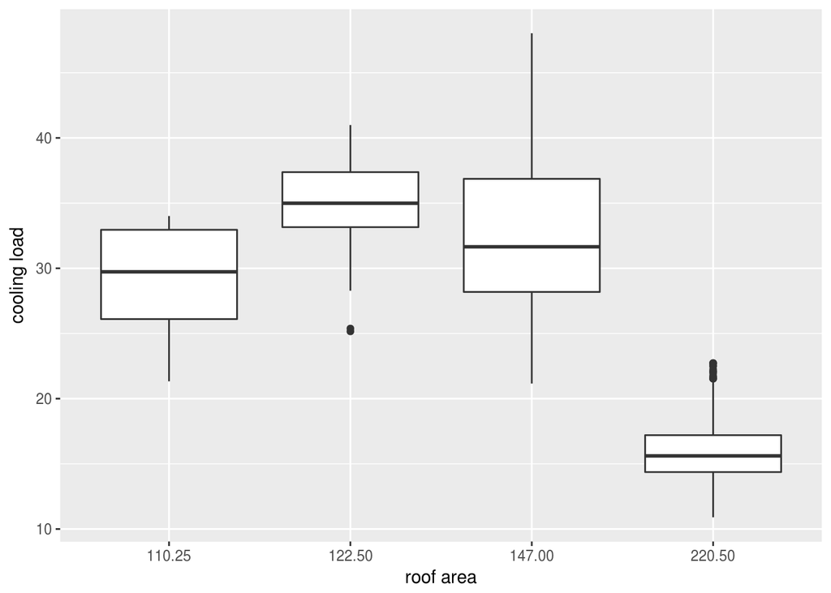

```r
ggplot(eedata, aes(y = cooling.load, x = roof.area)) + geom_boxplot() + labs(x = "roof area", y = "cooling load")
```

Next, I test the heating load

```r
testlm <- lm(heating.load ~ relative.compactness, data = eedatanumeric)
summary(testlm)
```

```
##
## Call:
## lm(formula = heating.load ~ relative.compactness, data = eedatanumeric)
##
## Residuals:
##     Min      1Q  Median      3Q     Max
## -19.569  -6.332  -1.028   3.393  19.259
##
## Coefficients:
##                      Estimate Std. Error t value Pr(>|t|)
## (Intercept)           -23.053      2.081  -11.08   <2e-16 ***
## relative.compactness   59.359      2.698   22.00   <2e-16 ***
## ---
## Signif. codes:  0 '***' 0.001 '**' 0.01 '*' 0.05 '.' 0.1 ' ' 1
##
## Residual standard error: 7.904 on 766 degrees of freedom
## Multiple R-squared:  0.3872, Adjusted R-squared:  0.3864
## F-statistic:   484 on 1 and 766 DF,  p-value: < 2.2e-16
```

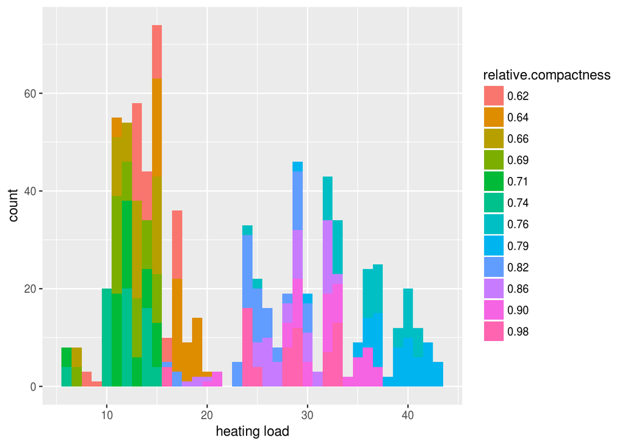

```r
ggplot(eedata, aes(x = heating.load, fill = relative.compactness)) + geom_histogram(binwidth = 1) + labs(x = "heating load")
```

```r
testlm <- lm(heating.load ~ surface.area, data = eedatanumeric)
summary(testlm)
```

```
##
## Call:
## lm(formula = heating.load ~ surface.area, data = eedatanumeric)
##
## Residuals:
##     Min      1Q  Median      3Q     Max
## -18.609  -5.524  -1.300   3.529  18.176
##
## Coefficients:
##               Estimate Std. Error t value Pr(>|t|)
## (Intercept)  72.945382   2.111062   34.55   <2e-16 ***
## surface.area -0.075387   0.003116  -24.19   <2e-16 ***
## ---
## Signif. codes:  0 '***' 0.001 '**' 0.01 '*' 0.05 '.' 0.1 ' ' 1
##
## Residual standard error: 7.602 on 766 degrees of freedom
## Multiple R-squared:  0.4331, Adjusted R-squared:  0.4324
## F-statistic: 585.3 on 1 and 766 DF,  p-value: < 2.2e-16
```

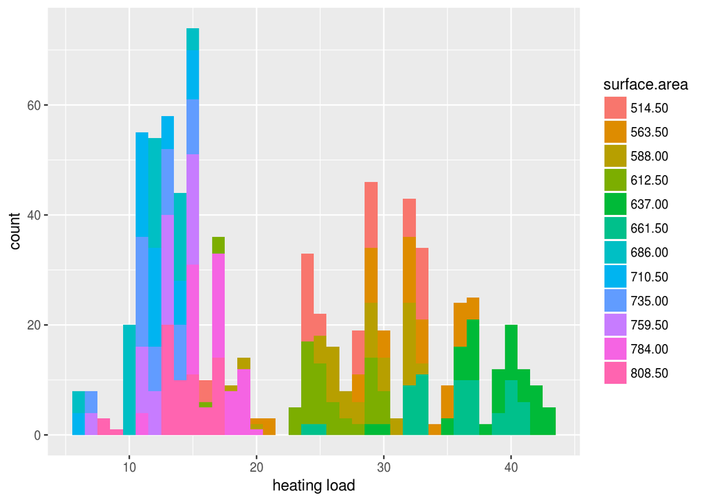

```r
ggplot(eedata, aes(x = heating.load, fill = surface.area)) + geom_histogram(binwidth = 1) + labs(x = "heating load")
```

```r
testlm <- lm(heating.load ~ wall.area, data = eedatanumeric)
summary(testlm)
```

```
##
## Call:
## lm(formula = heating.load ~ wall.area, data = eedatanumeric)
##
## Residuals:
##      Min       1Q   Median       3Q      Max
## -19.0213  -7.3937  -0.4882   7.5728  18.2107
##
## Coefficients:
##               Estimate Std. Error t value Pr(>|t|)
## (Intercept) -11.259633   2.391321  -4.709 2.96e-06 ***
## wall.area     0.105390   0.007439  14.168  < 2e-16 ***
## ---
## Signif. codes:  0 '***' 0.001 '**' 0.01 '*' 0.05 '.' 0.1 ' ' 1
##
## Residual standard error: 8.988 on 766 degrees of freedom
## Multiple R-squared:  0.2076, Adjusted R-squared:  0.2066
## F-statistic: 200.7 on 1 and 766 DF,  p-value: < 2.2e-16
```

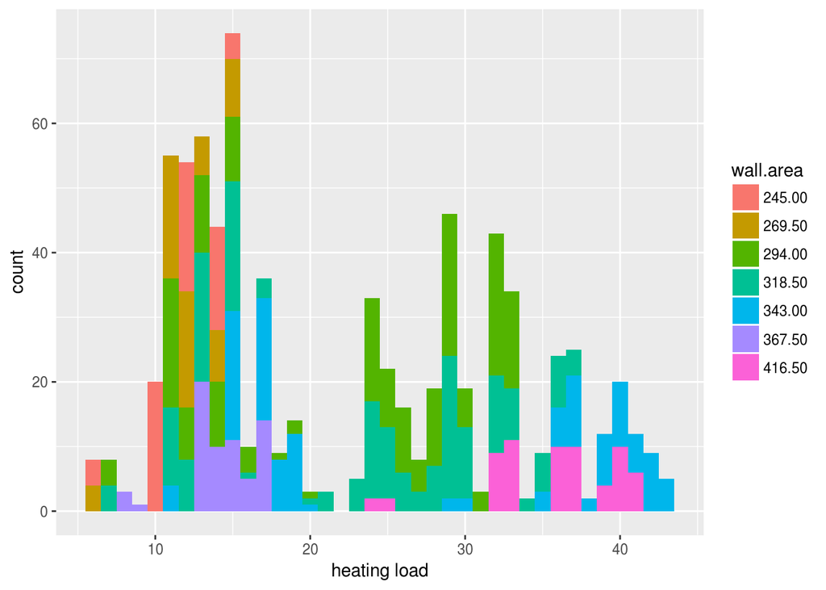

```r
ggplot(eedata, aes(x = heating.load, fill = wall.area)) + geom_histogram(binwidth = 1) + labs(x = "heating load")
```

```r
testlm <- lm(heating.load ~ glazing.area, data = eedatanumeric)
summary(testlm)
```

```
##
## Call:
## lm(formula = heating.load ~ glazing.area, data = eedatanumeric)
##
## Residuals:
##     Min      1Q  Median      3Q     Max
## -13.272  -9.193  -3.054   7.253  17.699
##
## Coefficients:
##              Estimate Std. Error t value Pr(>|t|)
## (Intercept)   17.5171     0.7103  24.662  < 2e-16 ***
## glazing.area  20.4379     2.6351   7.756  2.8e-14 ***
## ---
## Signif. codes:  0 '***' 0.001 '**' 0.01 '*' 0.05 '.' 0.1 ' ' 1
##
## Residual standard error: 9.722 on 766 degrees of freedom
## Multiple R-squared:  0.07281,    Adjusted R-squared:  0.0716
## F-statistic: 60.16 on 1 and 766 DF,  p-value: 2.796e-14
```

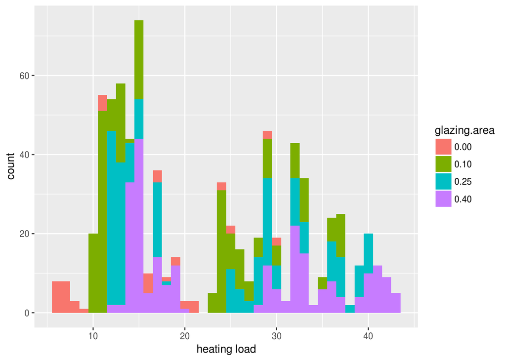

```r
ggplot(eedata, aes(x = heating.load, fill = glazing.area)) + geom_histogram(binwidth = 1) + labs(x = "heating load")
```

```r
testlm <- lm(heating.load ~ glazing.area.actual, data = eedatanumeric)
summary(testlm)
```

```
##
## Call:
## lm(formula = heating.load ~ glazing.area.actual, data = eedatanumeric)
##
## Residuals:
##     Min      1Q  Median      3Q     Max
## -13.340  -9.141  -1.956   7.972  18.367
##
## Coefficients:
##                      Estimate Std. Error t value Pr(>|t|)
## (Intercept)         15.990050   0.666772   23.98   <2e-16 ***
## glazing.area.actual  0.084625   0.007695   11.00   <2e-16 ***
## ---
## Signif. codes:  0 '***' 0.001 '**' 0.01 '*' 0.05 '.' 0.1 ' ' 1
##
## Residual standard error: 9.383 on 766 degrees of freedom
## Multiple R-squared:  0.1364, Adjusted R-squared:  0.1352
## F-statistic: 120.9 on 1 and 766 DF,  p-value: < 2.2e-16
```

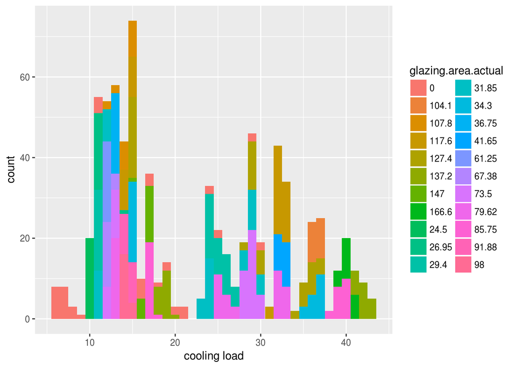

```r
ggplot(eedata, aes(x = heating.load, fill = glazing.area.actual)) + geom_histogram(binwidth = 1) + labs(x = "cooling load")
```

Similaraly, the heating response variable is greatly impacted by the overall height and roof area.

```r
testlm <- lm(heating.load ~ overall.height, data = eedatanumeric)
summary(testlm)
```

```
##
## Call:
## lm(formula = heating.load ~ overall.height, data = eedatanumeric)
##
## Residuals:
##      Min       1Q   Median       3Q      Max
## -15.7259  -2.5929  -0.3085   2.0015  11.8241
##
## Coefficients:
##                Estimate Std. Error t value Pr(>|t|)
## (Intercept)    -4.59885    0.52661  -8.733   <2e-16 ***
## overall.height  5.12496    0.09516  53.857   <2e-16 ***
## ---
## Signif. codes:  0 '***' 0.001 '**' 0.01 '*' 0.05 '.' 0.1 ' ' 1
##
## Residual standard error: 4.615 on 766 degrees of freedom
## Multiple R-squared:  0.7911, Adjusted R-squared:  0.7908
## F-statistic:  2901 on 1 and 766 DF,  p-value: < 2.2e-16
```

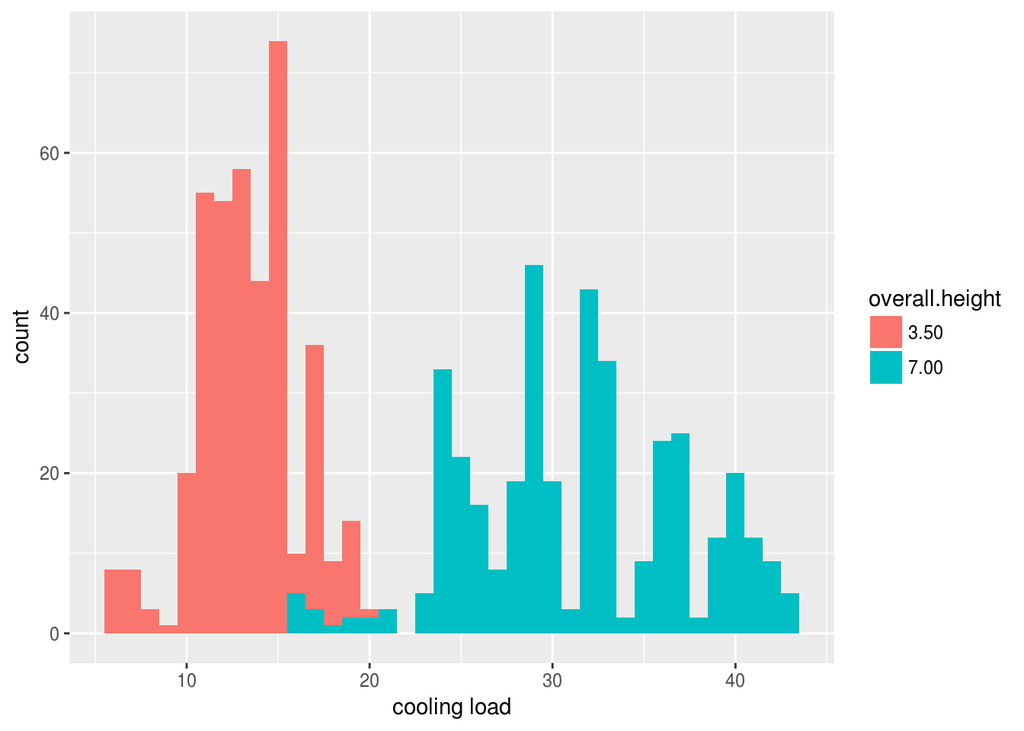

```r
ggplot(eedata, aes(x = heating.load, fill = overall.height)) + geom_histogram(binwidth = 1) + labs(x = "cooling load")
```

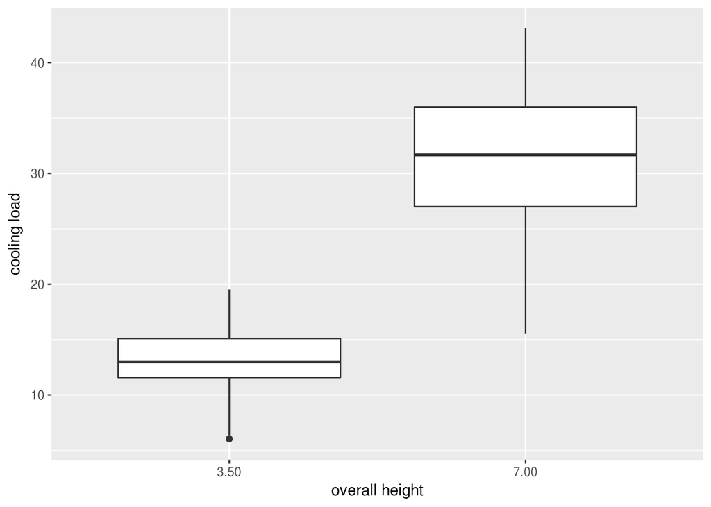

```r
ggplot(eedata, aes(y = heating.load, x = overall.height)) + geom_boxplot() + labs(x = "overall height", y = "cooling load")
```

```r
testlm <- lm(heating.load ~ roof.area, data = eedatanumeric)
summary(testlm)
```

```
##
## Call:
## lm(formula = heating.load ~ roof.area, data = eedatanumeric)
##
## Residuals:
##      Min       1Q   Median       3Q      Max
## -19.5327  -2.6392  -0.3191   2.4997  15.0930
##
## Coefficients:
##              Estimate Std. Error t value Pr(>|t|)
## (Intercept) 56.309643   0.746268   75.45   <2e-16 ***
## roof.area   -0.192535   0.004094  -47.03   <2e-16 ***
## ---
## Signif. codes:  0 '***' 0.001 '**' 0.01 '*' 0.05 '.' 0.1 ' ' 1
##
## Residual standard error: 5.121 on 766 degrees of freedom
## Multiple R-squared:  0.7427, Adjusted R-squared:  0.7424
## F-statistic:  2212 on 1 and 766 DF,  p-value: < 2.2e-16
```

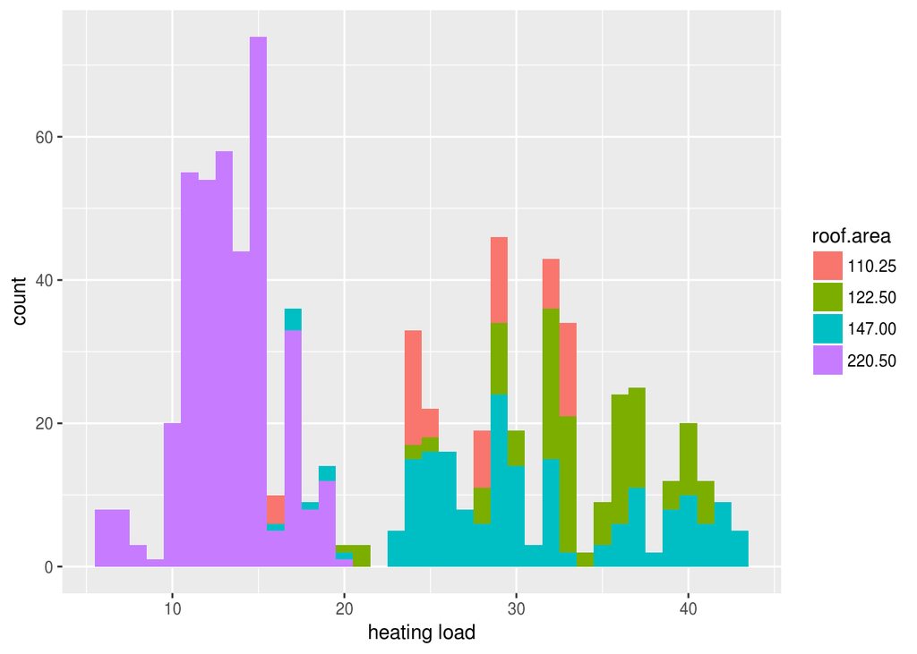

```r
ggplot(eedata, aes(x = heating.load, fill = roof.area)) + geom_histogram(binwidth = 1) + labs(x = "heating load")
```

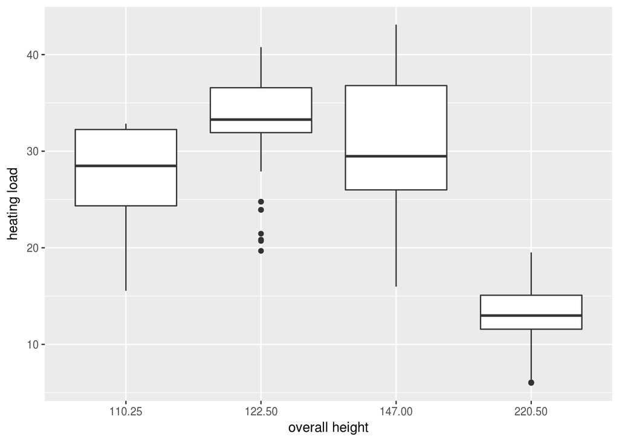

```r
ggplot(eedata, aes(y = heating.load, x = roof.area)) + geom_boxplot() + labs(x = "overall height", y = "heating load")
```

However, we see that only one roof area is applied to buildings with a 3.50 overall height and it appears to correlate to a much lower heating and cooling load

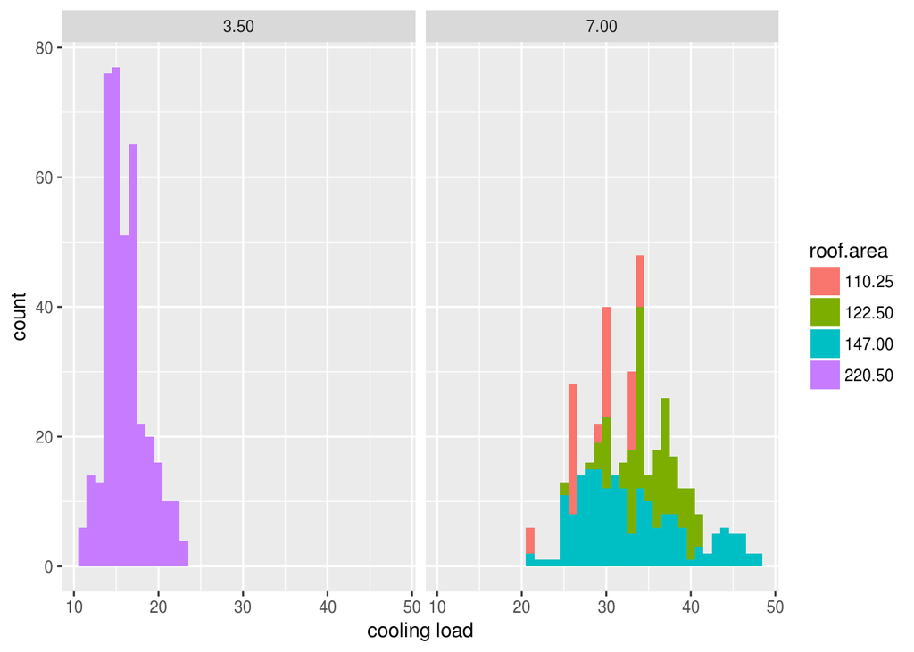

```r
ggplot(eedata, aes(x = cooling.load, fill = roof.area)) + geom_histogram(binwidth = 1) + labs(x = "cooling load") + facet_wrap(~overall.height)
```

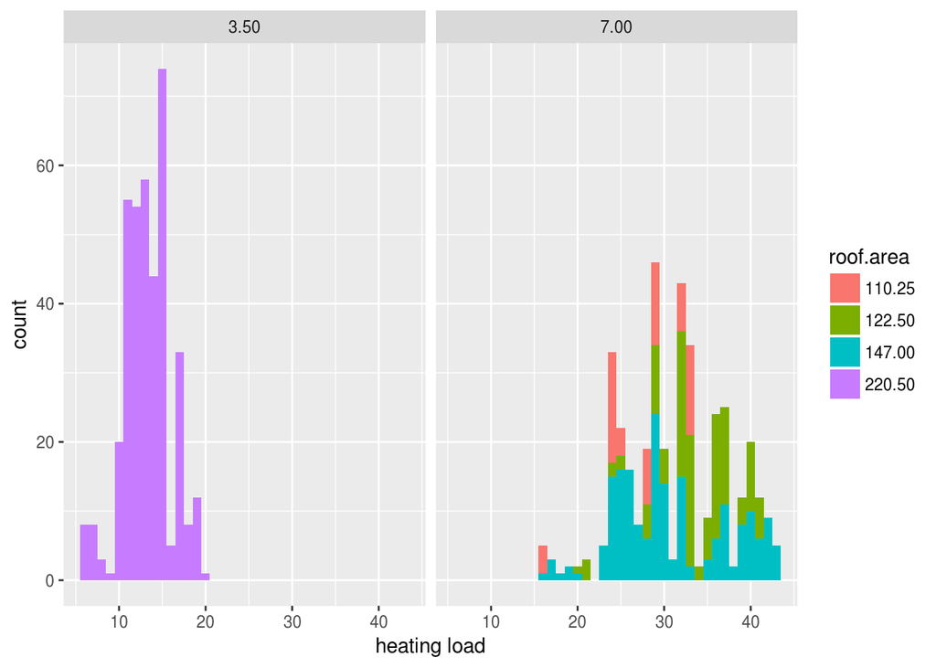

```r
ggplot(eedata, aes(x = heating.load, fill = roof.area)) + geom_histogram(binwidth = 1) + labs(x = "heating load") + facet_wrap(~overall.height)
```

So let’s split this data into two new tables where one is for 3.50 tall buildings and the other is for 7.0 tall buildings; I’m assuming the unit is meters from here on out.

```r
eedata3.50 <- subset(eedata, eedata$overall.height == "3.50")
eedata3.50numeric <- subset(eedatanumeric, eedata$overall.height < 6)
eedata7.00 <- subset(eedata, eedata$overall.height == "7.00")
eedata7.00numeric <- subset(eedatanumeric, eedata$overall.height > 4)
```

Now we can look at the 3.5m tall building histograms

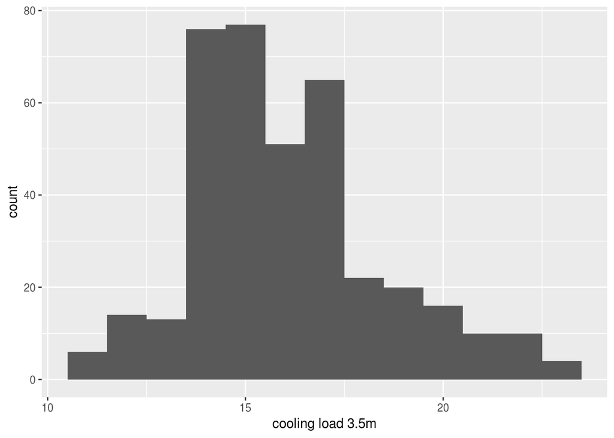

```r
ggplot(eedata3.50, aes(x = cooling.load)) + geom_histogram(binwidth = 1) + labs(x = "cooling load 3.5m")
```

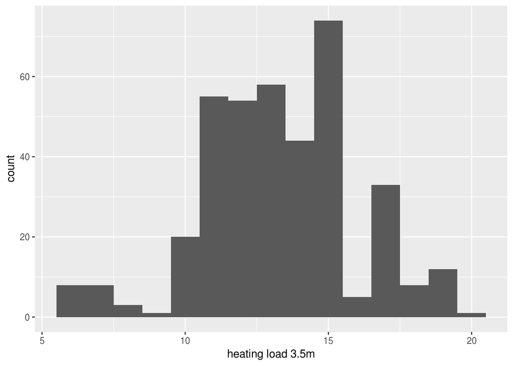

```r
ggplot(eedata3.50, aes(x = heating.load)) + geom_histogram(binwidth = 1) + labs(x = "heating load 3.5m")
```

Next, let’s re-run our cooling analysis

```r
testlm <- lm(cooling.load ~ relative.compactness, data = eedata3.50numeric)
summary(testlm)
```

```
##
## Call:
## lm(formula = cooling.load ~ relative.compactness, data = eedata3.50numeric)
##
## Residuals:
##     Min      1Q  Median      3Q     Max
## -5.3043 -1.4466 -0.2292  1.6271  5.8349
##
## Coefficients:
##                      Estimate Std. Error t value Pr(>|t|)
## (Intercept)            31.271      1.886  16.582  < 2e-16 ***
## relative.compactness  -22.463      2.782  -8.075 8.93e-15 ***
## ---
## Signif. codes:  0 '***' 0.001 '**' 0.01 '*' 0.05 '.' 0.1 ' ' 1
##
## Residual standard error: 2.24 on 382 degrees of freedom
## Multiple R-squared:  0.1458, Adjusted R-squared:  0.1436
## F-statistic:  65.2 on 1 and 382 DF,  p-value: 8.926e-15
```

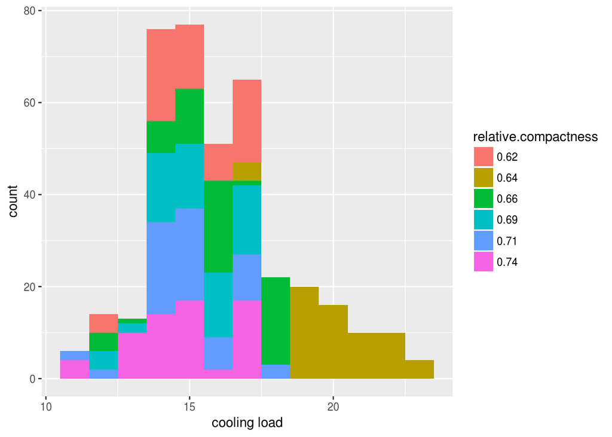

```r
ggplot(eedata3.50, aes(x = cooling.load, fill = relative.compactness)) + geom_histogram(binwidth = 1) + labs(x = "cooling load")
```

```r
testlm <- lm(cooling.load ~ surface.area, data = eedata3.50numeric)
summary(testlm)
```

```
##
## Call:
## lm(formula = cooling.load ~ surface.area, data = eedata3.50numeric)
##
## Residuals:
##     Min      1Q  Median      3Q     Max
## -5.3439 -1.4302 -0.1939  1.7036  5.8711
##
## Coefficients:
##              Estimate Std. Error t value Pr(>|t|)
## (Intercept)  0.059885   2.054806   0.029    0.977
## surface.area 0.021427   0.002746   7.804 5.79e-14 ***
## ---
## Signif. codes:  0 '***' 0.001 '**' 0.01 '*' 0.05 '.' 0.1 ' ' 1
##
## Residual standard error: 2.251 on 382 degrees of freedom
## Multiple R-squared:  0.1375, Adjusted R-squared:  0.1353
## F-statistic: 60.91 on 1 and 382 DF,  p-value: 5.789e-14
```

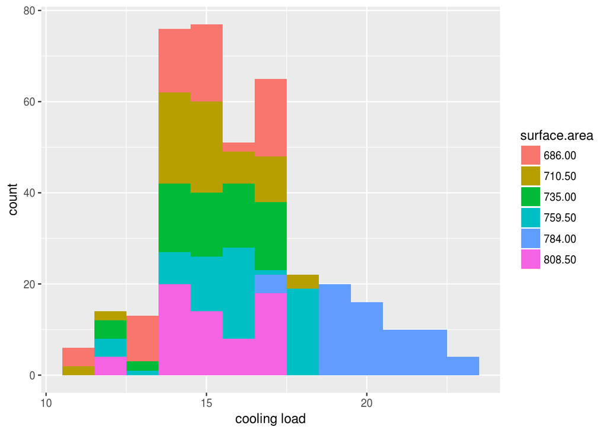

```r
ggplot(eedata3.50, aes(x = cooling.load, fill = surface.area)) + geom_histogram(binwidth = 1) + labs(x = "cooling load")
```

```r
testlm <- lm(cooling.load ~ wall.area, data = eedata3.50numeric)
summary(testlm)
```

```
##
## Call:
## lm(formula = cooling.load ~ wall.area, data = eedata3.50numeric)
##
## Residuals:
##     Min      1Q  Median      3Q     Max
## -5.3439 -1.4302 -0.1939  1.7036  5.8711
##
## Coefficients:
##             Estimate Std. Error t value Pr(>|t|)
## (Intercept) 9.509323   0.848628  11.206  < 2e-16 ***
## wall.area   0.021427   0.002746   7.804 5.79e-14 ***
## ---
## Signif. codes:  0 '***' 0.001 '**' 0.01 '*' 0.05 '.' 0.1 ' ' 1
##
## Residual standard error: 2.251 on 382 degrees of freedom
## Multiple R-squared:  0.1375, Adjusted R-squared:  0.1353
## F-statistic: 60.91 on 1 and 382 DF,  p-value: 5.789e-14
```

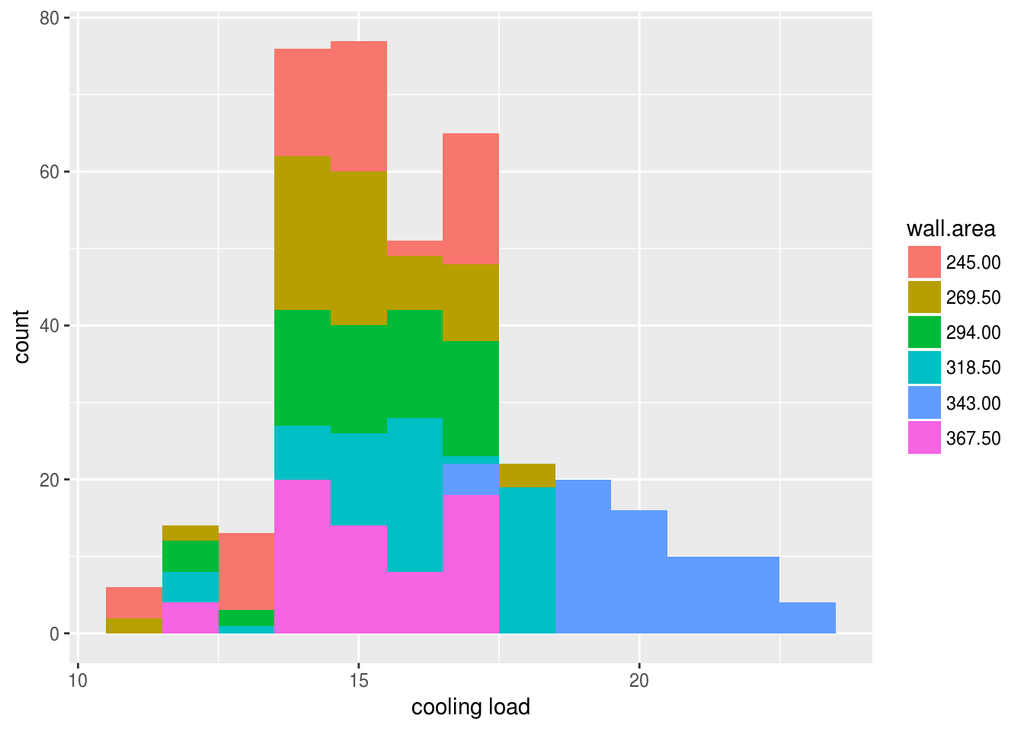

```r
ggplot(eedata3.50, aes(x = cooling.load, fill = wall.area)) + geom_histogram(binwidth = 1) + labs(x = "cooling load")
```

```r
testlm <- lm(cooling.load ~ glazing.area, data = eedata3.50numeric)
summary(testlm)
```

```
##
## Call:
## lm(formula = cooling.load ~ glazing.area, data = eedata3.50numeric)
##
## Residuals:
##     Min      1Q  Median      3Q     Max
## -3.2414 -1.1214 -0.6340 -0.0128  4.9535
##
## Coefficients:
##              Estimate Std. Error t value Pr(>|t|)
## (Intercept)   13.5950     0.2037   66.75   <2e-16 ***
## glazing.area  10.5660     0.7557   13.98   <2e-16 ***
## ---
## Signif. codes:  0 '***' 0.001 '**' 0.01 '*' 0.05 '.' 0.1 ' ' 1
##
## Residual standard error: 1.971 on 382 degrees of freedom
## Multiple R-squared:  0.3385, Adjusted R-squared:  0.3368
## F-statistic: 195.5 on 1 and 382 DF,  p-value: < 2.2e-16
```